# CO2 Flux

Justin Pomeranz - J Pomz

11/30/2020

## Standardizing variables to assist with prior selection

CO2 data from the COSORE package Bond‐Lamberty, B, Christianson, DS, Malhotra, A, et al. COSORE: A community database for continuous soil respiration and other soil‐atmosphere greenhouse gas flux data. Glob Change Biol. 2020; 26: 7268– 7283. https://doi.org/10.1111/gcb.15353

Simplified dataset, looking at mean CO2 fluxes from deciduous broadleaf forests in the northern hemisphere

```r
library(tidyverse)
d <- readRDS("data/co2_july.RDS")
```

I have no idea what a “normal” CO2 flux is, or even what a range would be. So the data includes a scaled (CO2<sub>i</sub> / max(CO2)) and standardized (Z-score; (CO2<sub>i</sub> - mean(CO2)) / SD(CO2) ) version of the CO2 variable.

```r
names(d)
```

```
## [1] "data_set"  "co2_flux"  "latitude"  "co2_scale" "co2_std"   "lat_scale"
## [7] "lat_std"
```

I have also included a scaled and standardized version of the latitude variable.

Below, I use the scaled version of each
$$I'M NOT SURE WHICH TO USE ?? let's chat$$

The scaled transformation means that CO2 flux is now between 0-1. We want to leave 0, as this is a biologically relevant measurement, i.e., $no$ CO2 flux.

let’s assume a linear relationship of co2 flux with lattitude. The full Bayesian model can be described as:
$$Mean CO_{2} flux_{site} \sim dnorm(\mu, \sigma)$$
$$\mu = \alpha + \beta * Latitude_i$$
$$\alpha \sim dnorm(\mu, \sigma)$$
$$\beta \sim dnorm(\mu, \sigma)$$
$$\sigma \sim dexp(\delta)$$

Becasue this is scaled between 0 and 1, a reasonable expectation for the intercept, , is 0.5. We will give it a SD of 1 to start with.

I have no idea if we should expect a positive or negative relatinoship with latitude, so we will center at 0, and give it a flat SD of 10.

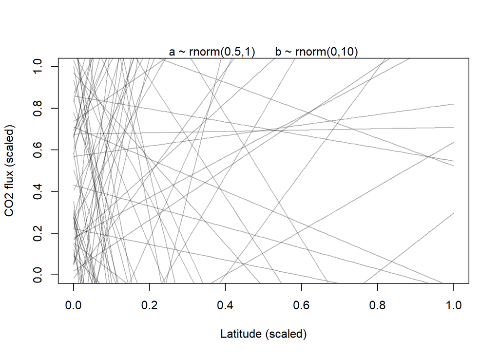

```r
set.seed(1225)
N <- 100
a <- rnorm(N, 0.5, 1) # prior distribution of alpha
b <- rnorm(N, 0, 10) # prior distribution of beta

# set plot axis limits
xlim = c(0, 1)
ylim = c(0, 1)
# setup the plot
plot(NULL, xlim = xlim, ylim = ylim,
     xlab = "Latitude (scaled)", ylab = "CO2 flux (scaled)")
mtext(("a ~ rnorm(0.5,1)      b ~ rnorm(0,10)"))

# plot 100 lines based on the prior distributions
for (i in 1:N){
  curve(a[i] + b[i]*x,
        from = 0,
        to = 1,
        add = TRUE,
        col = gray(0, 0.3))
}
```

Taming down the beta:

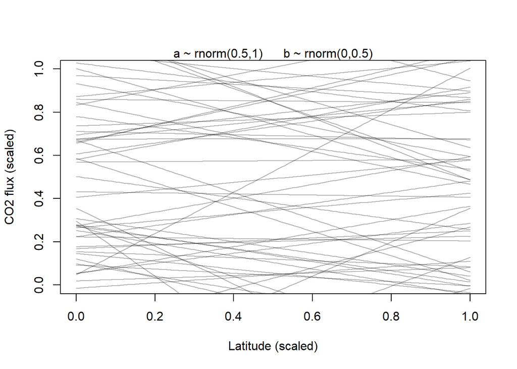

```r
set.seed(1225)
N <- 100
a <- rnorm(N, 0.5, 1) # prior distribution of alpha
b <- rnorm(N, 0, 0.5) # prior distribution of beta

# set plot axis limits
xlim = c(0, 1)
ylim = c(0, 1)
# setup the plot
plot(NULL, xlim = xlim, ylim = ylim,
     xlab = "Latitude (scaled)", ylab = "CO2 flux (scaled)")
mtext(("a ~ rnorm(0.5,1)      b ~ rnorm(0,0.5)"))

# plot 100 lines based on the prior distributions
for (i in 1:N){
  curve(a[i] + b[i]*x,
        from = 0,
        to = 1,
        add = TRUE,
        col = gray(0, 0.3))
}
```

Force to be closer to mean CO2 flux

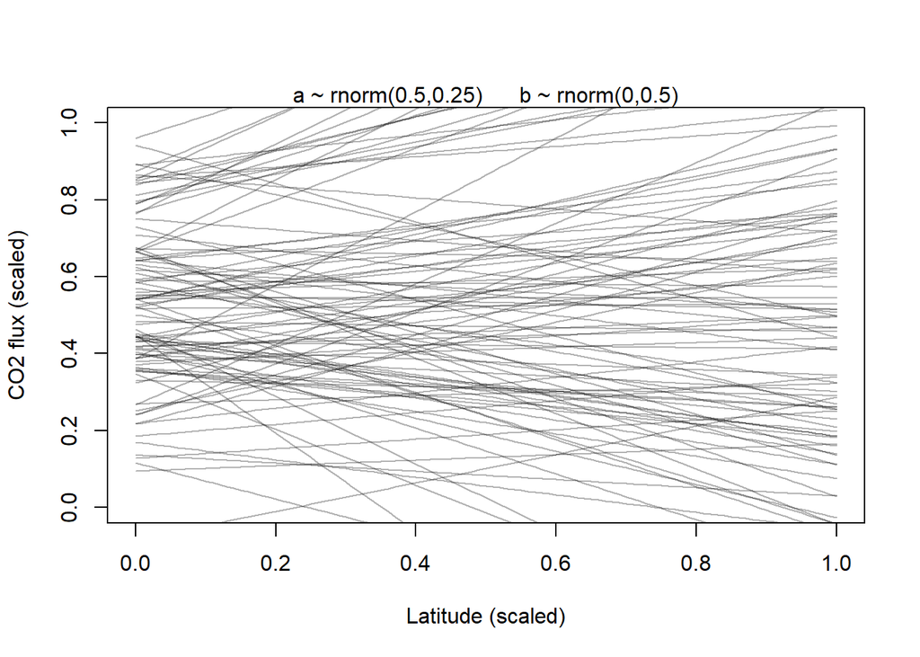

```r
set.seed(1225)
N <- 100
a <- rnorm(N, 0.5, 0.25) # prior distribution of alpha
b <- rnorm(N, 0, 0.5) # prior distribution of beta

# set plot axis limits
xlim = c(0, 1)
ylim = c(0, 1)
# setup the plot
plot(NULL, xlim = xlim, ylim = ylim,
     xlab = "Latitude (scaled)", ylab = "CO2 flux (scaled)")
mtext(("a ~ rnorm(0.5,0.25)      b ~ rnorm(0,0.5)"))

# plot 100 lines based on the prior distributions
for (i in 1:N){
  curve(a[i] + b[i]*x,
        from = 0,
        to = 1,
        add = TRUE,
        col = gray(0, 0.3))
}
```

This limits the priors to be within the expected observation space, while still allowing for some pretty extreme relationships